# Scratch Research

Abdelmalek Hajjam

10/19/2020

## reading the cleaned data

```r
#Fully cleaned and imputed dataset
data <- read.csv("diabetic_cleanedANDprocessed.csv", header = TRUE, strip.white = TRUE)
data$readmitted <- as.factor(data$readmitted)
dim(data)
```

```
## [1] 70420    42
```

```r
table(data$readmitted)
```

```
##
##     0     1
## 64129  6291
```

##Imbalance data Problem

Because we have an imbalanced Dataset with respect to the class. Accuracy therefore is not a robust measure of classifier performance in presence of a class imbalance. Accuracy is not the metric to use when working with an imbalanced dataset. It is misleading. There are metrics that have been designed to tell you a more truthful story when working with imbalanced classes, such as Precision, Recall and F Beta. in this case, we will use AUC (area under the curve) as our metric for this classfication problem. But before that, we will have to balance our training dataset so that the model will not be bias to the majority class. In our case, we will use the SMOTE function found in the DMwR package.

## Training and Test data set up

```r
library(DMwR) # for SMOTE
library(caret)
library(mltools)
set.seed(123)
# Step 1: Get row numbers for the training data (80% train split, 20% testing split)
trainRowNumbers <- createDataPartition(data$readmitted, p=0.8, list=FALSE)
#training  dataset
trainData <- data[trainRowNumbers,]
#test dataset
testData <- data[-trainRowNumbers,]

# set the target variable as a factor
trainData$readmitted <- as.factor(trainData$readmitted)
testData$readmitted <- as.factor(testData$readmitted)

table(data$readmitted)
```

```
##
##     0     1
## 64129  6291
```

```r
table(trainData$readmitted)
```

```
##
##     0     1
## 51304  5033
```

```r
table(testData$readmitted)
```

```
##
##     0     1
## 12825  1258
```

```r
#Because our dataset is imbalanced. we use smote to create a balanced training set
trainData$readmitted <- as.factor(trainData$readmitted)
trainData_SMOTE <- SMOTE(readmitted ~ ., trainData)

table(trainData_SMOTE$readmitted)
```

```
##
##     0     1
## 20132 15099
```

## Logistic Regression

```r
library(kableExtra)

LR <- glm(readmitted ~ ., data = trainData_SMOTE, family = "binomial")

LR_pred <- predict(LR, testData, type = 'response')
LR_pred_labels <- ifelse(LR_pred > 0.5 , 1, 0)
cm_LR <-  table(LR_pred_labels, testData$readmitted)
cm_LR
```

```
##
## LR_pred_labels     0     1
##              0 10319   830
##              1  2506   428
```

```r
acc_LR <- sum(diag(cm_LR)) / sum(cm_LR)
print(paste("accuracy: ", acc_LR))
```

```
## [1] "accuracy:  0.763118653695945"
```

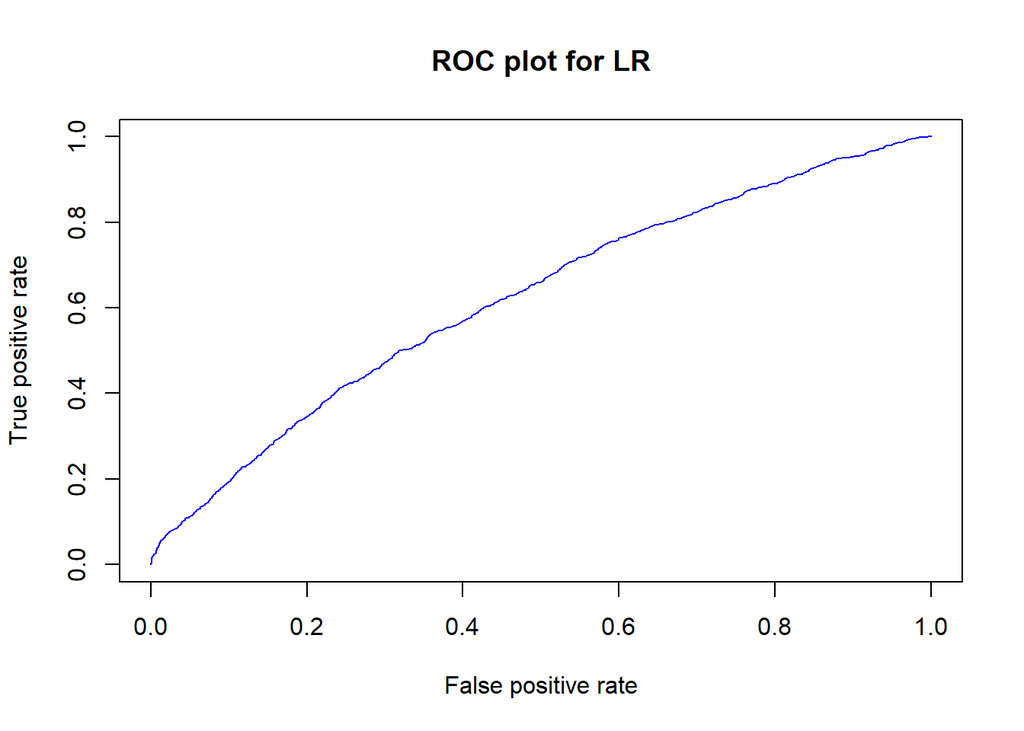

```r
tpr_LR <- cm_LR[1,1]/sum(cm_LR[1,1], cm_LR[2,1])
fpr_LR <- cm_LR[1,2]/sum(cm_LR[1,2], cm_LR[2,2])
tnr_LR <- 1 - fpr_LR
fnr_LR <- 1 - tpr_LR

library(ROCR)
ROCRpred <- prediction(LR_pred, testData$readmitted)
ROCRperf <- performance(ROCRpred, 'tpr', 'fpr')
plot(ROCRperf, col="blue", main="ROC plot for LR")
```

```r
ROCRperfauc <- performance(ROCRpred, 'auc')
auc_LR <- ROCRperfauc@y.values[[1]]

Generalizing_LRrow <- c("LR",round(auc_LR,2),round(acc_LR,2),round(tpr_LR,2),round(fpr_LR,2),round(tnr_LR,2),round(fnr_LR,2))
kable(Generalizing_LRrow)
```

| x |
| --- |
| LR |
| 0.62 |
| 0.76 |
| 0.8 |
| 0.66 |
| 0.34 |
| 0.2 |

```r
#"accuracy:  0.763118653695945"
```

## Naive Bayes

```r
 library(e1071)
 NB <- naiveBayes(readmitted ~ ., data = trainData_SMOTE)

NB_pred <- predict(NB, testData)
NB_pred_raw <- predict(NB, testData, type = "raw")

#confusion matrix
cm_NB <-  table(NB_pred, testData$readmitted)

acc_NB <- sum(diag(cm_NB))/sum(cm_NB)
print(paste("accuracy: ", acc_NB))
```

```
## [1] "accuracy:  0.551516012213307"
```

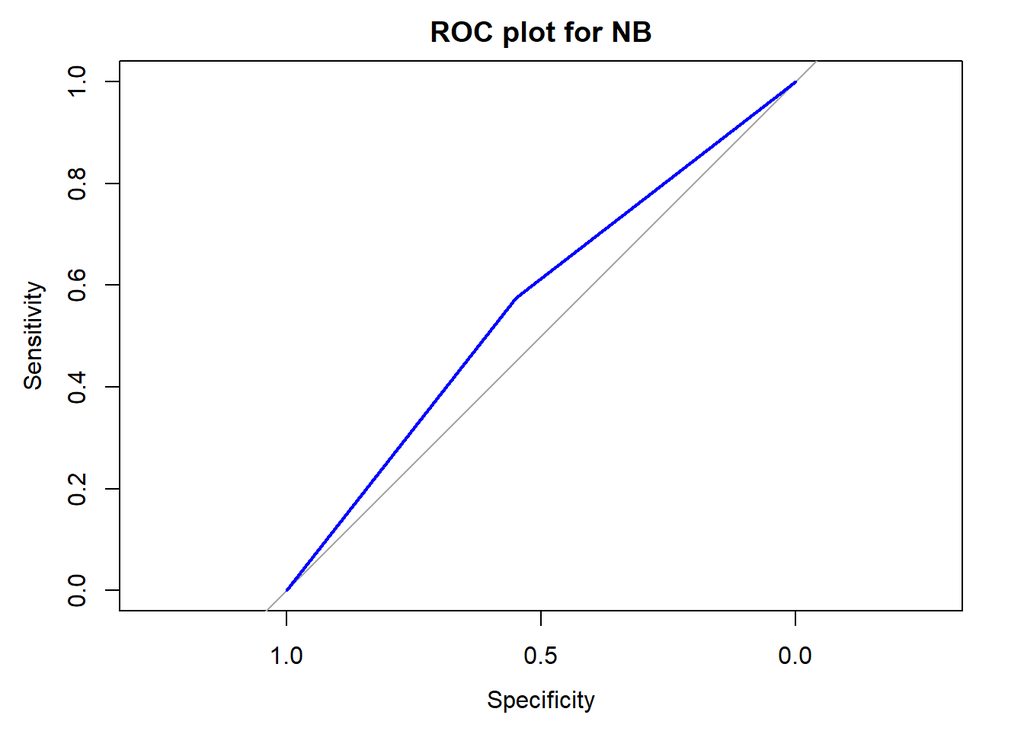

```r
tpr_NB <- cm_NB[1,1]/sum(cm_NB[1,1], cm_NB[2,1])
fpr_NB <- cm_NB[1,2]/sum(cm_NB[1,2], cm_NB[2,2])
tnr_NB <- 1 - fpr_NB
fnr_NB <- 1 - tpr_NB

library(pROC)
roc_NB <- roc(testData$readmitted, as.numeric(NB_pred))
auc_NB <- roc_NB$auc
plot(roc_NB,col="blue",main="ROC plot for NB")
```

```r
Generalizing_NBrow <- c("NB",round(auc_NB,2),round(acc_NB,2),round(tpr_NB,2),round(fpr_NB,2),round(tnr_NB,2),round(fnr_NB,2) )
kable(Generalizing_NBrow)
```

| x |
| --- |
| NB |
| 0.56 |
| 0.55 |
| 0.55 |
| 0.43 |
| 0.57 |
| 0.45 |

```r
#"accuracy:  0.551516012213307"
```

## KNN

```r
# KNN - Learning (k=125)

library(class)
KNNFit <- knn3(readmitted ~., data = trainData_SMOTE, k=125)

library(class)

#apply the model to the test data
KNN <- predict(KNNFit, newdata = testData, type = "class")

#confusion matrix
cm_KNN <-  table(KNN, testData$readmitted)
cm_KNN
```

```
##
## KNN     0     1
##   0 11116  1035
##   1  1709   223
```

```r
acc_KNN <- sum(diag(cm_KNN))/sum(cm_KNN)
print(paste("accuracy: ", acc_KNN))
```

```
## [1] "accuracy:  0.805155151601221"
```

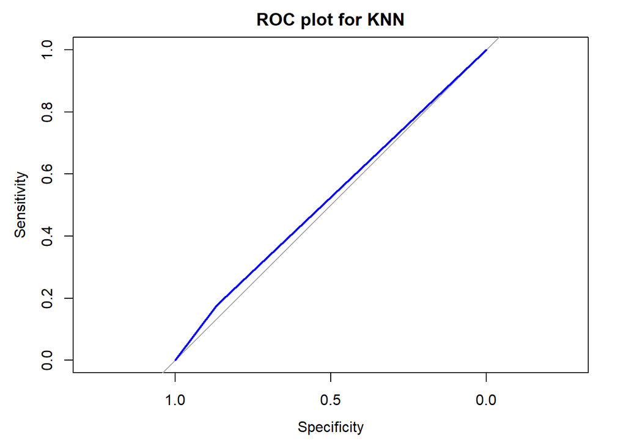

```r
tpr_KNN <- cm_KNN[1,1]/sum(cm_KNN[1,1], cm_KNN[2,1])
fpr_KNN <- cm_KNN[1,2]/sum(cm_KNN[1,2], cm_KNN[2,2])
tnr_KNN <- 1 - fpr_KNN
fnr_KNN <- 1 - tpr_KNN

library(pROC)
roc_KNN <- roc(testData$readmitted, as.numeric(KNN))
auc_KNN <- roc_KNN$auc
plot(roc_KNN, col="blue",main="ROC plot for KNN")
```

```r
Generalizing_KNNrow <- c("KNN",round(auc_KNN,2),round(acc_KNN,2),round(tpr_KNN,2),round(fpr_KNN,2), round(tnr_KNN,2),round(fnr_KNN,2) )
kable(Generalizing_KNNrow )
```

| x |
| --- |
| KNN |
| 0.52 |
| 0.81 |
| 0.87 |
| 0.82 |
| 0.18 |
| 0.13 |

```r
#"accuracy:  0.805155151601221"
```